# Bumble bees, then and now: mapping change on Galiano Island

2026-07-04

Historical museum specimens and present-day community science observations rarely speak to each other directly — different collectors, different effort, different decades. But laid side by side, they can reveal quiet shifts in a pollinator community that neither record shows alone.

**Key idea** — absence of a record is not evidence of absence. A species can be locally extirpated for years before that absence is even noticed, let alone confirmed.

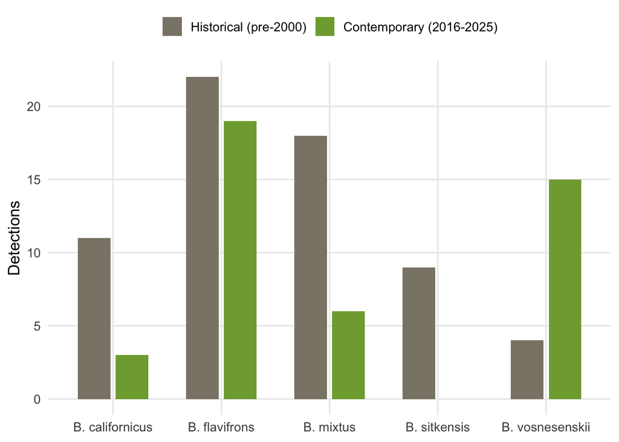

Community-mapped survey effort itself is worth showing, not just summarizing — search effort is part of the evidence, not just a caveat.

[interactive chart not shown]

Historical records compiled from museum specimen databases (e.g. GBIF-mediated collections). Contemporary records drawn from community-mapped iNaturalist observations, 2016–2025, restricted to research-grade identifications. Search effort estimated from GPS track density, following the same approach used in the [extirpation detection protocol](https://github.com/IMERSS/detecting-local-extinction).

This kind of comparison is really a small-scale version of the same question at the heart of [Simon, Best & Starzomski (2023)](https://doi.org/10.3955/046.096.0305) — what does it take to responsibly claim a species has disappeared from a place, rather than simply gone unnoticed? It is also, not coincidentally, the same question the diatom monitoring work and the broader extirpation framework keep returning to at different scales.

### Related

[**Biodiversity Galiano**Community-based biodiversity monitoring on Galiano Island](http://biogaliano.org) [**IMERSS**Institute for Multidisciplinary Ecological Research in the Salish Sea](https://imerss.org) [**Detecting extirpation**Protocol and documentation for the extirpation detection method](https://github.com/IMERSS/detecting-local-extinction)